# Descritivo de Remunerações do TJPB de 2018 a 2020

# Paraíba

## TJPB - 2018 a 2020

## Análise Descritiva

### Distribuição dos funcionários no TJPB de 2018 a 2020

Em julho de 2020 o TJPB apresentava um total de **4278** funcionários.

#### Geral por mês

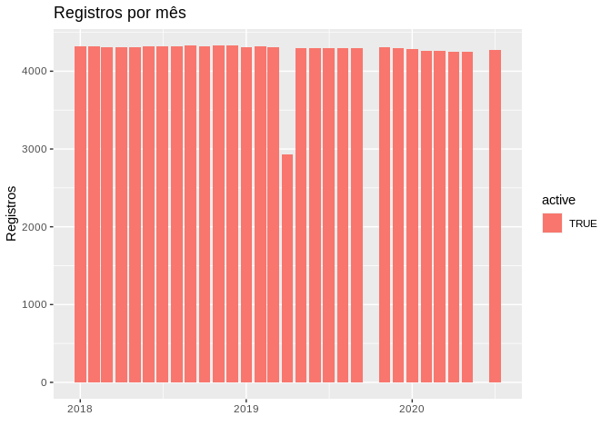

#### Ativos por tipo

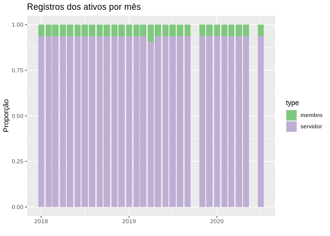

#### Distribuição geral por tipo (em jul de cada ano)

| Tipo | 2018 | 2019 | 2020 |
| --- | --- | --- | --- |
| membro | 277 | 274 | 269 |
| servidor | 4041 | 4025 | 4009 |

- Membros: É uma classificação mais ampla que abrange todo o tipo agente público que “representa” o Poder Judiciário ou o Ministério Público.
- Servidores: Um servidor público é um funcionário da administração pública que possui um vínculo de trabalho com órgãos que fazem parte do Estado.

### Visão geral dos pagamentos de 2018 a 2020

Os pagamentos medianos, máximos e mínimos se deram da seguinte forma.

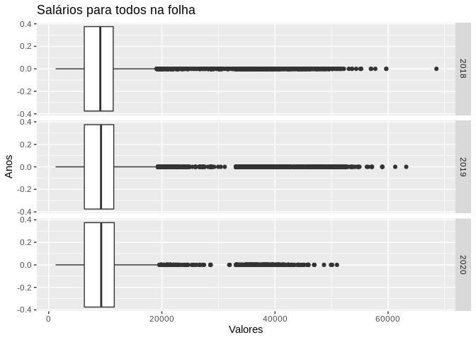

### Distribuição dos tipos dos gastos de 2018 a 2020

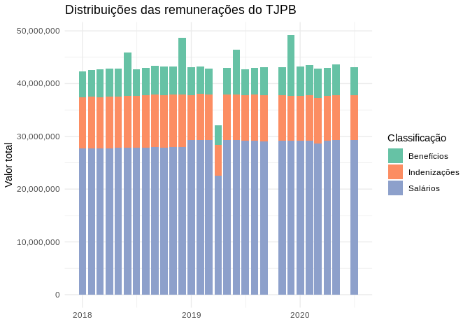

Os benefícios aqui descritos são quaisquer remunerações recebidas por um funcionário que não sejam proveniente de salários ou indenizações. Alguns exemplos de benefícios são: diárias, gratificações, remuneração por função de confiança, benefícios pessoais ou eventuais.

As indenizações, por sua vez, são valores especiais recebidos eventualmente. Por exemplo: Auxílios alimentação, moradia, transporte, natalidade, pré-escolar, ajudas de custo.

### Remunerações médias dos funcionários de acordo com seu tipo

| Ano | membro | servidor |
| --- | --- | --- |
| 2018 | 37419.05 | 8226.513 |
| 2019 | 38754.07 | 8265.241 |
| 2020 | 36748.06 | 8338.390 |

### Distribuição das remunerações dos funcionários de acordo com seu tipo

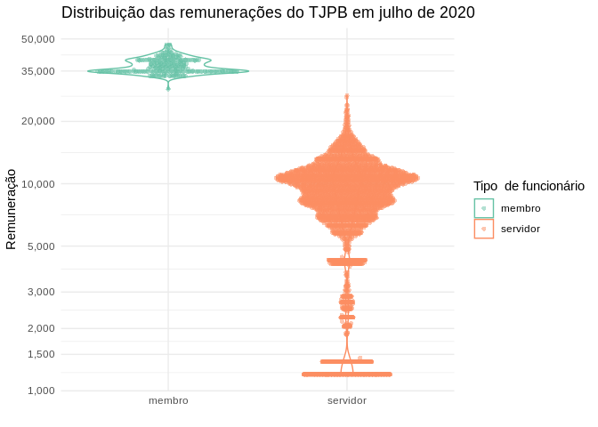

### Distribuição das remunerações de 2018 a 2020

#### Média dos salários por ano

| Ano | Média |
| --- | --- |
| 2018 | 10097.02 |
| 2019 | 10262.63 |
| 2020 | 10134.46 |

#### Distribuição dos salários por ano

Na distribuição das remunerações de 2018 existem funcionários com remuneração acima de **R$ 60.000,00** e outros com remuneração abaixo de **R$ 5.000,00**. A média salárial foi de **R$ 10.097,02**

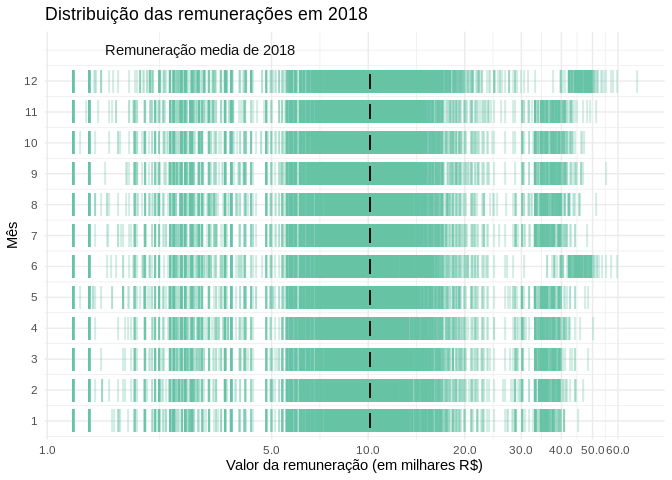

Em 2019 existem funcinários com remuneração acima de **R$ 60.000,00** e outros com remuneração abaixo de **R$ 5.000,00**. A média salárial foi de **R$ 10.262,00**

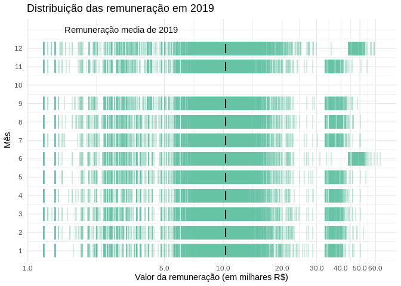

Em 2020 existem funcinários com remuneração acima de **R$ 50.000,00** e outros com remuneração abaixo de **R$ 5.000,00**. A média salárial foi de **R$ 10.134,46**, até então.

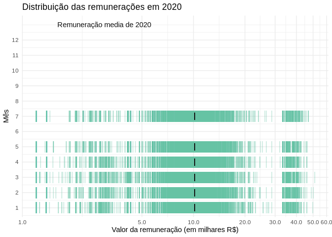

### Distribuição das remunerações por cargo

Diversos cargos acumulam remunerações acima de **R$ 30.000,00**. Entre eles, temos: Juíz, Diretor de Fórum, Desembargador, e vários outros. Cargos como Técnico Judiciário, Oficial de Justiça, Chefe de Cartório, apresentam rendimentos abaixo de **R$ 25.000,00**, bem como grande parte dos cargos restantes.

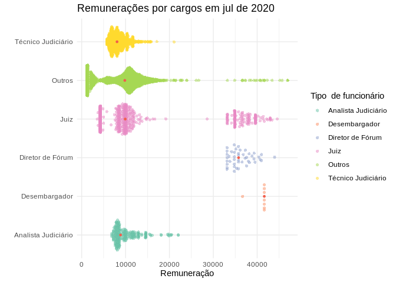

### Distribuição dos tipos de auxílios e indenizações

#### Benefícios

| Ano | Benefícios Eventuais | Benefícios Pessoais | Cargo de Confiança | Total |
| --- | --- | --- | --- | --- |
| 2018 | 22516582 | 10149888 | 36989054 | 71148351 |
| 2019 | 22930385 | 10031361 | 30187844 | 64687277 |
| 2020 | 8606562 | 5871491 | 18386736 | 33432132 |

Benefícios Permanentes (funds_personal_benefits) são os benefícios adquiridos judicialmente e outros benefícios pessoais. Benefícios Eventuais (funds_eventual_benefits), são benefícios como bônus de natal e férias. Já Cargos de Confiança (funds_trust_position) são benefícios recebidos por funcionários em cargos de confiança.

Os outros benefícios, **funds_daily**, **funds_gratification**, **funds_origin_pos** e **funds_others_total**, não possuem valores associados, em todos os anos.

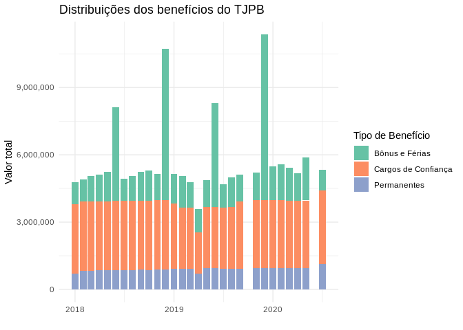

A fonte principal dos aumentos recorrentes nessa categoria é os benefícios eventuais, como bônus e férias (funds_eventual_benefits). Os outros benefícios se mantém estáveis.

#### Indenizações

| Ano | Total |
| --- | --- |
| 2018 | 118125758 |
| 2019 | 92302761 |
| 2020 | 51091886 |

O único valor presente é o referente ao total das indenizações (perks_total). As indenizações específicas não possuem valores associados. **perks_pecuniary**, **perks_food**, **perks_health**, **perks_compensatory_leave**, **perks_birth**, **perks_housing**, **perks_subsistence**, **perks_vacation**, **perks_transportation**, **perks_pre_school**, **perks_vacation_pecuniary**, **perks_furniture_transport**, **perks_premium_license_pecuniary** são todos NA, em todos os anos.

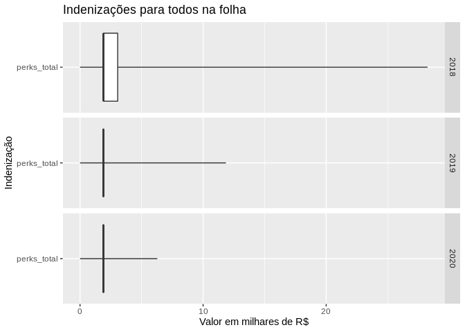

Um valor chama atenção em 2018. Em dezembro, um Diretor de Fórum - Nível II recebeu **R$ 28.232,48** de indenização, valor quase treze vezes mais alto que a média no mesmo ano, que foi de **R2.250,00**.

#### Por membros ativos

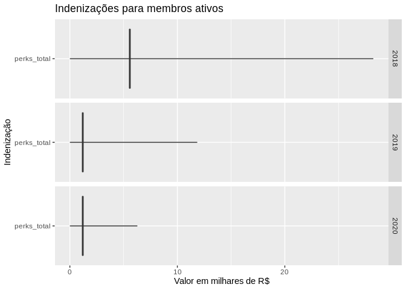

### Distribuição dos principais cargos em julho de 2020

| Cargo | Quantidade |
| --- | --- |
| TECNICO JUDICIARIO | 993 |
| OFICIAL DE JUSTIÇA | 796 |
| A DISPOSIÇÃO | 639 |
| ASSESSOR DE GAB. DO JUIZO DE 1o GRAU | 381 |
| CHEFE DE CARTORIO | 202 |
| ANALISTA JUDICIARIO | 155 |
| AUXILIAR JUDICIARIO | 136 |
| JUIZ DE DIREITO DE 3A. ENTRANCIA | 100 |
| ASSISTENTE JURIDICO | 84 |
| SUPERVISOR | 67 |
| CHEFE DA CENTRAL DE MANDADOS E DE DISTRIBUIÇÃO I | 45 |
| JUIZ DE DIREITO AUXILIAR | 42 |
| GERENTE DE FÓRUM - NÍVEL I | 40 |
| JUIZ DE DIREITO DE 2A. ENTRANCIA | 39 |
| ASSESSOR DE GABINETE | 34 |
| DIRETOR DE FÓRUM - NÍVEL I | 32 |
| ANALISTA JUDICIARIO - ESP ASSISTENTE SOCIAL | 26 |
| ANALISTA JUDICIARIO - ESP PSICOLOGIA | 22 |
| ASSESSOR DE GABINETE DO JUIZO DE 1a CIRCUNSCRIÇÃO JUDICIARIA | 21 |
| TÉCNICO JUDICIÁRIO - ESPECIALIDADE TAQUIGRAFIA | 21 |
| OFICIAL JUDICIARIO II | 20 |
| OFICIAL JUDICIARIO III | 20 |